# Sentiment Analysis using tidy data

Saumya Mehta

5/14/2018

## sentiments dataset

Tidytext package contains several sentiment lexicons in sentiments dataset.

```r
library(tidytext)
sentiments
```

```
## # A tibble: 27,314 x 4
##    word        sentiment lexicon score
##    <chr>       <chr>     <chr>   <int>
##  1 abacus      trust     nrc        NA
##  2 abandon     fear      nrc        NA
##  3 abandon     negative  nrc        NA
##  4 abandon     sadness   nrc        NA
##  5 abandoned   anger     nrc        NA
##  6 abandoned   fear      nrc        NA
##  7 abandoned   negative  nrc        NA
##  8 abandoned   sadness   nrc        NA
##  9 abandonment anger     nrc        NA
## 10 abandonment fear      nrc        NA
## # ... with 27,304 more rows
```

- 3 general purpose lexicons :
  - AFINN
  - bing
  - nrc
- All these lexicons are based on unigrams.
- They contain english words with scores for positive/ negative sentiment.
- nrc categorizes in binary fashion into categories of positive, negative, anger, anticipation, disgust, fear, joy, sadness, surprise, and trust.
- The bing lexicon categorizes words in a binary fashion into positive and negative categories.
- The AFINN lexicon assigns words with a score that runs between -5 and 5, with negative scores indicating negative sentiment and positive scores indicating positive sentiment.
- get_sentiment to get specific sentiment columns without the columns that are not used in that lexicon.

```r
get_sentiments("afinn")
```

```
## # A tibble: 2,476 x 2
##    word       score
##    <chr>      <int>
##  1 abandon       -2
##  2 abandoned     -2
##  3 abandons      -2
##  4 abducted      -2
##  5 abduction     -2
##  6 abductions    -2
##  7 abhor         -3
##  8 abhorred      -3
##  9 abhorrent     -3
## 10 abhors        -3
## # ... with 2,466 more rows
```

```r
get_sentiments("bing")
```

```
## # A tibble: 6,788 x 2
##    word        sentiment
##    <chr>       <chr>
##  1 2-faced     negative
##  2 2-faces     negative
##  3 a+          positive
##  4 abnormal    negative
##  5 abolish     negative
##  6 abominable  negative
##  7 abominably  negative
##  8 abominate   negative
##  9 abomination negative
## 10 abort       negative
## # ... with 6,778 more rows
```

```r
get_sentiments("nrc")
```

```
## # A tibble: 13,901 x 2
##    word        sentiment
##    <chr>       <chr>
##  1 abacus      trust
##  2 abandon     fear
##  3 abandon     negative
##  4 abandon     sadness
##  5 abandoned   anger
##  6 abandoned   fear
##  7 abandoned   negative
##  8 abandoned   sadness
##  9 abandonment anger
## 10 abandonment fear
## # ... with 13,891 more rows
```

Dictionary sentiments find the total sentiment of a piece of text by adding the individual sentiment score for each word in the text.  
These methods do not take into account qualifier before words such as “no good”, or “not true”. A lexicon based method like this is based on unigrams only.  
Size of the chunk of text that we use to add up unigram scores can have effect on analysis.  
A text the size of many paragraphs can often have positive and negative sentiment averaged out to about zero, while sentence-sized or paragraph-sized text often works better.

## Sentiment analysis with inner join

Removing stop words is an anti-join operation. Performing sentiment analysis is an inner join operation.  
Preparing data for sentiment analysis:

```r
library(janeaustenr)
library(dplyr)
library(stringr)
tidy_books <- austen_books() %>%
  group_by(book) %>%
  mutate(line_number = row_number(),
         chapter = cumsum(str_detect(text,regex("^chaper [\\divxlc]", ignore_case =T)))) %>%
  ungroup() %>%
  unnest_tokens(word,text)
```

Filter nrc for joy sentiment and then inner join tidy_books with resulting frame.

```r
nrc_joy <- get_sentiments("nrc") %>%
  filter(sentiment == "joy")
tidy_books %>%
  filter(book == "Emma") %>%
  inner_join(nrc_joy) %>%
  count(word, sort = T)
```

```
## # A tibble: 303 x 2
##    word        n
##    <chr>   <int>
##  1 good      359
##  2 young     192
##  3 friend    166
##  4 hope      143
##  5 happy     125
##  6 love      117
##  7 deal       92
##  8 found      92
##  9 present    89
## 10 kind       82
## # ... with 293 more rows
```

Smaller sections of text do not have enough words in them and larger sections can wash out narritive structutre.

```r
library(tidyr)
jane_austen_sentiment <- tidy_books %>%
  inner_join(get_sentiments("bing")) %>%
  count(book, index = line_number %/% 80, sentiment) %>%
  spread(sentiment, n, fill = 0) %>%
  mutate(sentiment = positive- negative)
```

Sentiment scores across the plot trajectory of each novel.

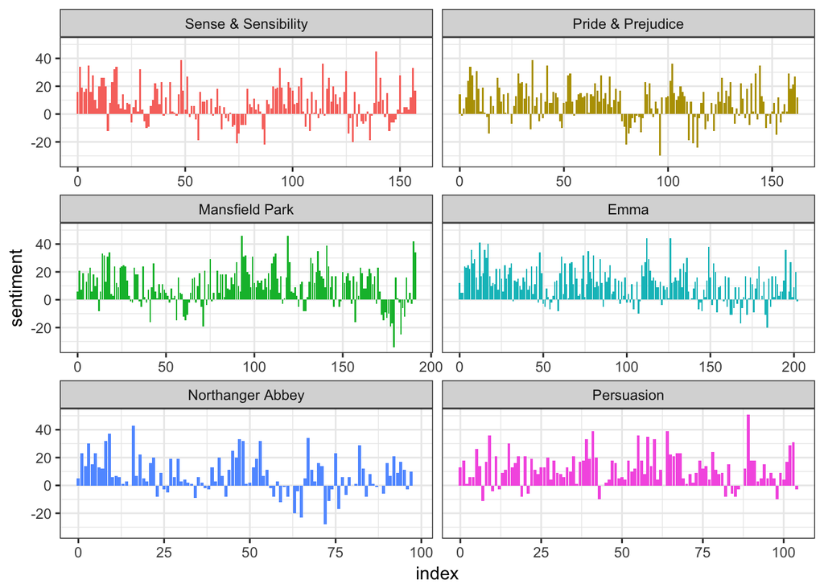

Figure 2.1: Sentiment through the narratives of Jane Austen’s novels

## Comparing three sentiment dictionaries.

```r
pride_prejudice <- tidy_books %>%
  filter(book == "Pride & Prejudice")
```

```r
afinn <- pride_prejudice %>%
  inner_join(get_sentiments("afinn")) %>%
  group_by(index = line_number %/% 80) %>%
  summarise(sentiment = sum(score)) %>%
  mutate(method = "Afinn")
bing_and_nrc <- bind_rows(pride_prejudice %>%
                            inner_join(get_sentiments("bing")) %>%
                            mutate(method = "Bing et al."),
                          pride_prejudice %>%
                            inner_join(get_sentiments("nrc") %>%
                                         filter(sentiment %in% c("positive",
                                                                 "negative"))) %>%
                            mutate(method = "NRC")) %>%
  count(method, index = line_number %/% 80, sentiment) %>%
  spread(sentiment, n, fill = 0) %>%
  mutate(sentiment = positive - negative)
```

Now we have estimate of net sentiment for each chunk of novel text for each sentiment lexicon.

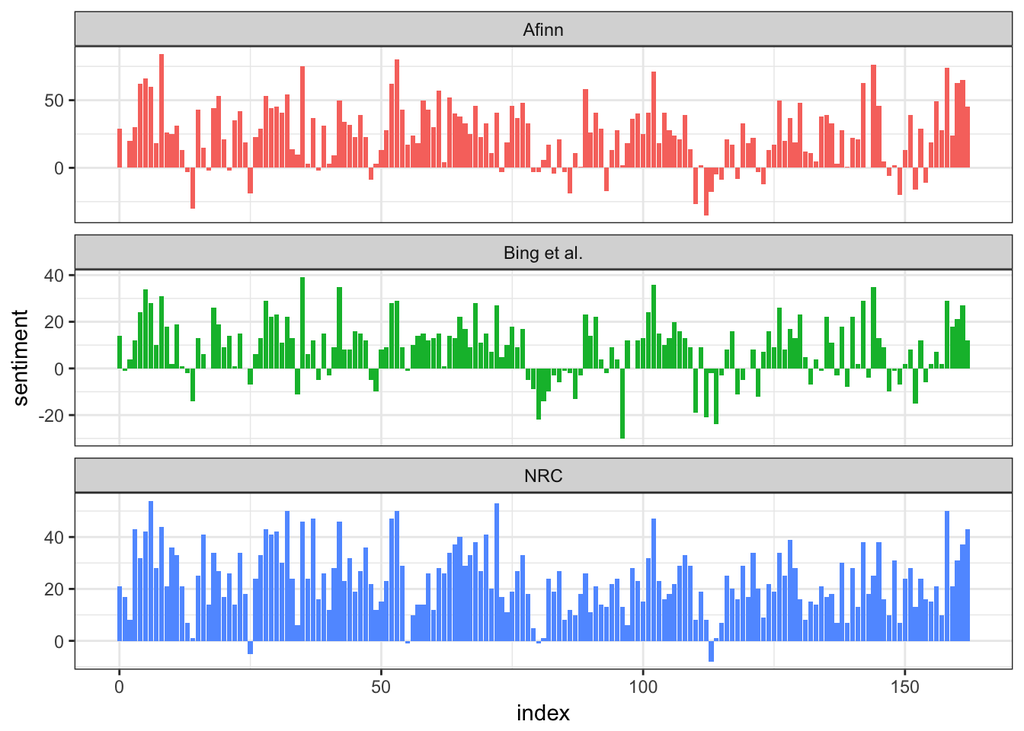

Figure 2.2: Comparing three sentiment lexicons using Pride and Prejudice

NRC sentiment is high, AFINN has more variance and Bing et.all finds longer stretches of similar texts.

## Most common positive and negative words.

By including count along with word and sentiment, we can find out how much the word contributed to each sentiment.

```r
big_word_counts <- tidy_books %>%
  inner_join(get_sentiments("bing")) %>%
  count(word, sentiment, sort = T) %>%
  ungroup()
big_word_counts
```

```
## # A tibble: 2,585 x 3
##    word     sentiment     n
##    <chr>    <chr>     <int>
##  1 miss     negative   1855
##  2 well     positive   1523
##  3 good     positive   1380
##  4 great    positive    981
##  5 like     positive    725
##  6 better   positive    639
##  7 enough   positive    613
##  8 happy    positive    534
##  9 love     positive    495
## 10 pleasure positive    462
## # ... with 2,575 more rows
```

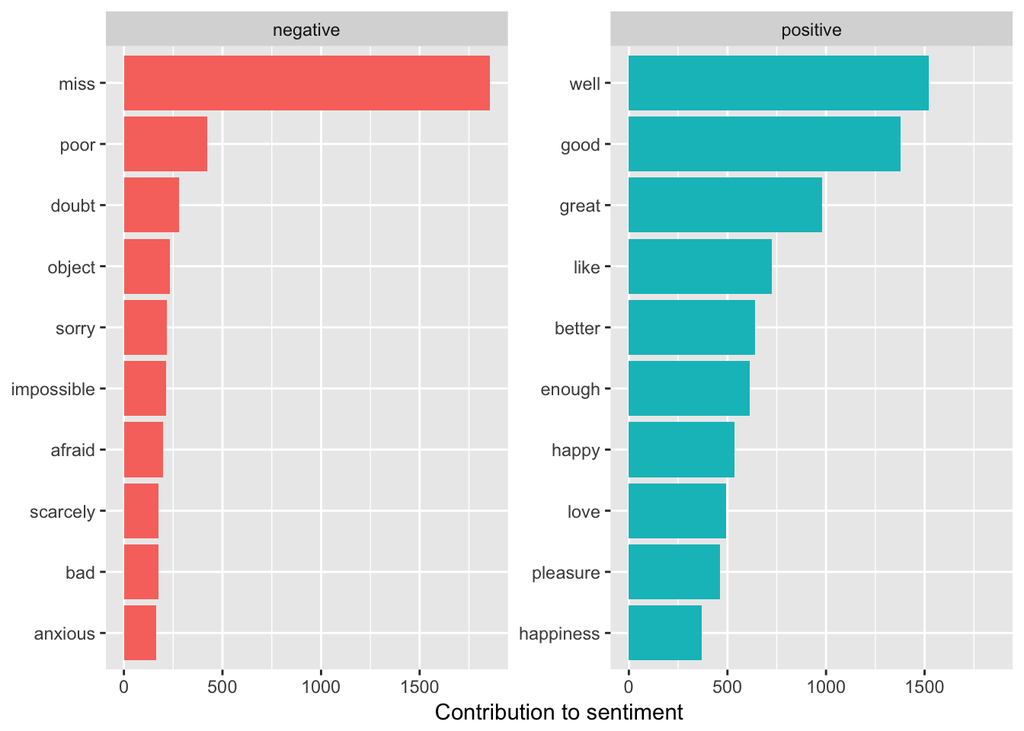

Figure 2.3: Words that contribute to positive and negative sentiment in Jane Austen’s novels

Here miss is considered as negative sentiment but can be used to address young women. We can add miss to our custom stop words and filter it out along with other stop words.

```r
custom_stop_words <- bind_rows(data.frame(word = c("miss"),
                                          lexicon = c("custom")), stop_words)
custom_stop_words
```

```
##               word  lexicon
## 1             miss   custom
## 2                a    SMART
## 3              a's    SMART
## 4             able    SMART
## 5            about    SMART
## 6            above    SMART
## 7        according    SMART
## 8      accordingly    SMART
## 9           across    SMART
## 10        actually    SMART
## 11           after    SMART
## 12      afterwards    SMART
## 13           again    SMART
## 14         against    SMART
```

[output cut: 1136 more lines]

## Word Cloud

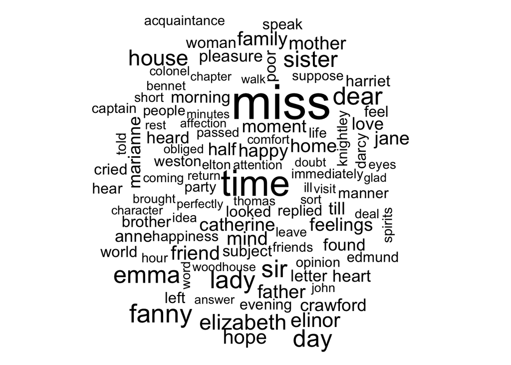

Figure 2.4: The most common words in Jane Austen’s novels

Comparision cloud can be used to make a word cloud of positive and negative sentiments. We need to reshape the data into a matrix.

```r
library(reshape2)
```

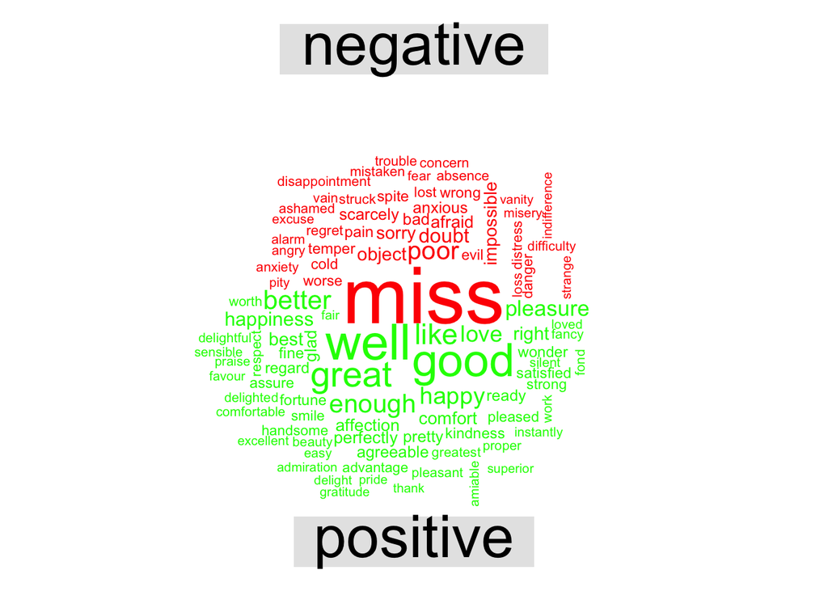

```r
tidy_books %>%
  inner_join(get_sentiments("bing")) %>%
  count(word, sentiment, sort = T) %>%
  acast(word ~ sentiment, value.var = "n", fill = 0) %>%
  comparison.cloud(colors = c("red","green"),
                   max.words = 100)
```

## Looking at units beyond words

Some algorithms look beyond unigrams and try to understand the sentiment of the sentence as a whole. Some R packages capable to do such things are coreNLP, cleanNLP, sentimentr.

```r
PandP_sentences <- data_frame(text = prideprejudice) %>%
  unnest_tokens(sentence, text, token = "sentences")

PandP_sentences$sentence[2]
```

```
## [1] "however little known the feelings or views of such a man may be on his first entering a neighbourhood, this truth is so well fixed in the minds of the surrounding families, that he is considered the rightful property of some one or other of their daughters."
```

```r
austen_chapters <- austen_books() %>%
  group_by(book) %>%
  unnest_tokens(chapter, text, token = "regex",
                pattern = "Chapter|CHAPTER [\\dIVXLC]") %>%
  ungroup()

austen_chapters %>%
  group_by(book) %>%
  summarise(chapters = n())
```

```
## # A tibble: 6 x 2
##   book                chapters
##   <fct>                  <int>
## 1 Sense & Sensibility       51
## 2 Pride & Prejudice         62
## 3 Mansfield Park            49
## 4 Emma                      56
## 5 Northanger Abbey          32
## 6 Persuasion                25
```

```r
bingnegative <- get_sentiments("bing") %>%
  filter(sentiment == "negative")

wordcounts <- tidy_books %>%
  group_by(book, chapter) %>%
  summarize(words = n())

tidy_books %>%
  semi_join(bingnegative) %>%
  group_by(book, chapter) %>%
  summarize(negativewords = n()) %>%
  left_join(wordcounts, by = c("book", "chapter")) %>%
  mutate(ratio = negativewords/words) %>%
  top_n(1) %>%
  ungroup()
```

```
## # A tibble: 6 x 5
##   book                chapter negativewords  words  ratio
##   <fct>                 <int>         <int>  <int>  <dbl>
## 1 Sense & Sensibility       0          3671 119957 0.0306
## 2 Pride & Prejudice         0          3652 122204 0.0299
## 3 Mansfield Park            0          4828 160460 0.0301
## 4 Emma                      0          4809 160996 0.0299
## 5 Northanger Abbey          0          2518  77780 0.0324
## 6 Persuasion                0          2201  83658 0.0263
```